# STAT340 HW02: Monte Carlo

Jeffrey Hui

September 24, 2022

## Instructions

Update the “author” and “date” fields in the header and complete the exercises below. Knit the document, and submit **both the HTML and Rmd** files to Canvas.

**Due date:** September 29, 2022 at 11:59pm.

## Exercise 1: Generalized [birthday problem](https://en.wikipedia.org/wiki/Birthday_problem)

The birthday problem asks for the probability that in a group of $n$ people, at least 2 people will share the same birthday. This is a standard question in introductory probability; see lecture for a solution.

In this problem, we will generalize the birthday problem to a more difficult question and then solve it using a Monte Carlo approach.

**Question:** in $n$ people, what is the probability that at least $k$ people have the same birthday?

Write a function `birthday(n, k, m)` takes 3 arguments:

- $n$ is the number of people in your sample
  - for example, if `n = 50` is used, we are asking “in 50 people, what is the probability that…”
- $k$ is minimum number of people that must share a birthday
  - for example if `k = 4` is used, we asking “…what is the probability that at least 4 people share the same birthday?
- $m$ is the number of iterations to run (default 1000)
  - for example, if `m = 1000` is used, your function should run 1000 simulations

`birthday(n, k, m)` should return a Monte Carlo estimate, based on `m` Monte Carlo replicates, of the probability that among `n` people, at least `k` of them have the same birthday.

**Notes:**

- You may assume there are 365 possible dates (no leap years)
- You may assume birthdays are uniformly distributed across the calendar
  - this is actually not true; see [this](https://www.panix.com/~murphy/bday.html), or [this](https://fivethirtyeight.com/features/lots-of-parents-dont-want-their-kids-to-be-born-on-leap-day/), but we’re going to make the simplifying assumption.
- You may assume the people are sampled [i.i.d.](https://en.wikipedia.org/wiki/Independent_and_identically_distributed_random_variables).

**Hints:**

1. There’s no need to use actual dates in the simulation process. Numbers can represent dates and are easier to generate and manipulate in `R`. In particular, we recommend using the `sample()` function with the `x`, `size`, and `replace` arguments set appropriately. See the help page `?sample` for details.
2. Given a vector of numbers, you can easily find duplicates by using the `table()` function. This will produce a named vector showing how many of each value there are. For example, running `table(c(1, 3, 5, 5, 7, 9, 9, 9))` will show you there is one 1, one 3, two 5s, one 7, and three 9s.
3. In your function, you will need to use a `for` loop to repeat the simulation `i` times. You will also need a variable outside your `for` loop to keep track of how many simulations satisfy that # of birthdays $\geq k$.
4. If your function is running correctly, then `birthday(n = 23, k = 2)`, `birthday(n = 87, k = 3)` and `birthday(n = 188, k = 4)` should all be approximately $50\%$.
5. If your function is very slow, consider using the [`Table` function](https://rdrr.io/cran/Rfast/man/Table.html) from the Rfast package, which is 4-5 times faster than the normal `table()` function.

```r
# Reminder: m = 1000 sets the default value of m to be 1000
birthday <- function(n, k, m = 1000) {
  bday_ge_k = 0
  for (i in 1:m) {
    bdays = sample(365, size = n, replace = TRUE)
    if (max(table(bdays)) >= k) {
      bday_ge_k = bday_ge_k + 1
    }
  }
  return (bday_ge_k / m)
}
birthday(n = 241, k = 5, m = 2000)
```

```
## [1] 0.2075
```

This class currently has 241 enrolled students (across two sections). Use your function to estimate the approximate probability that at least $5$ students have the same birthdays? Use `m = 2000` Monte Carlo replicates.

## Exercise 2: Simulating a random variable

Define a random variable $X$ with density
$$f_X(t) = \begin{cases}
2t &\mbox{ if } 0 \le t \le 1 \\
0 &\mbox{ otherwise. }
\end{cases}$$

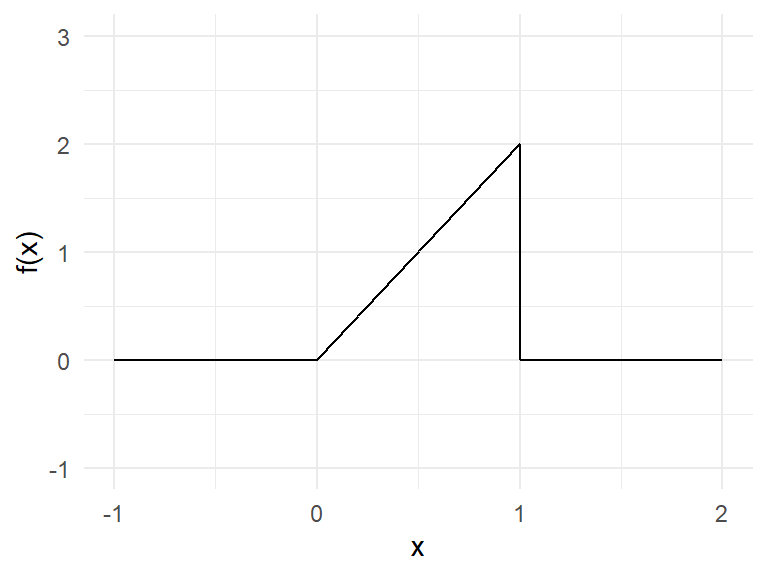

```r
# here we define a *vectorized* function to evaluate the probability density
# function (pdf) of X by using pmin() and pmax(), which are vectorized
# versions of min() and max()
pdf_x <- function(x) {
  # ifelse is like a function version of an if statement.
  # We use it here to ensure that pdf_x can operate directly on vectors.
  return( ifelse( 0 <= x & x <= 1, 2*x, 0 ) )
}

library(ggplot2)
# showing the PDF in a plot
ggplot() +
  geom_function(fun = pdf_x, n = 10001) +
  theme_minimal() +
  xlim(c(-1, 2)) +
  ylim(-1, 3) +
  labs(x = "x", y = "f(x)")
```

This means that the cumulative distribution function is
$$F_X(t)=\int_0^t f_X(u) du=t^2$$
for $0 \le t \le 1$, and $F_X(t) = 1$ for $t \ge 1$. Write a function `rx(n)` (like `rbinom`) to sample from this random variable, where `n` is the size of the sample to be drawn. Then, use your function to draw sample of size 500 and plot a histogram of the output.

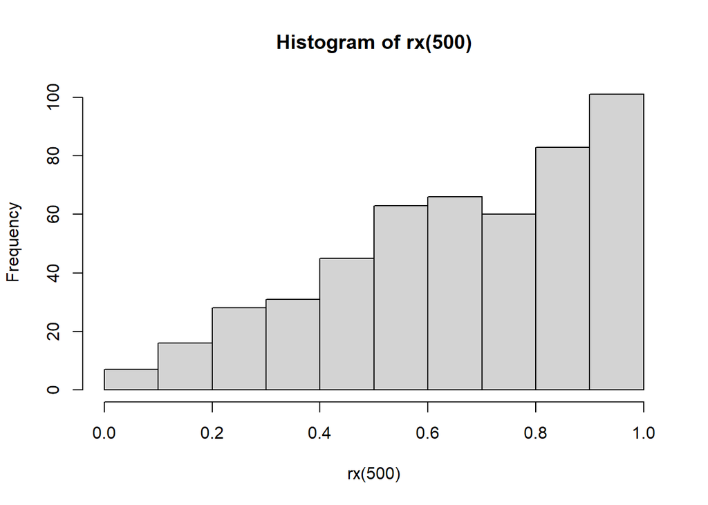

```r
# complete the function
rx <- function(n) {
  return (sqrt(runif(n, min = 0, max = 1)))
}

# The histogram should look like the PDF we plotted above.
# Uncomment the following line of code and check it looks correct
hist(rx(500))
```

## Exercise 3: records

According to a U.N. Report from earlier this year, the warmest seven years on record have all been since 2015. That is, the years 2015, 2016, 2017, 2018, 2019, 2020 and 2021 were the seven warmest years (though not necessarily in order) since record-keeping began circa 1850.

Let’s simplify things a bit, and suppose that records exist just for the past 10 years, with the first recorded temperature in 2012 and with 2021 being the last year (since 2022 hasn’t quite finished, yet).

Suppose that the average temperatures for the past 10 years were random with no trend. Then we would expect that any of the 10 years on record is equally likely to be the hottest on record, any of the remaining 9 years on record is equally likely to be the second hottest on record, etc. Use Monte Carlo to estimate the probability that, under this model in which all temperature orderings are equally likely, the seven warmest years on record occur during the seven years ending in 2021.

**Hint:** a completely equivalent question asks, if we order the numbers 1 to 10 completely at random, what is the probability that the numbers $\{1, 2, 3, 4, 5, 6, 7 \}$ appear in the first seven entries in the ordering? Bear in mind that this *does not* require that 1 appear first in the ordering, 2 second, etc., only that the first seven numbers appear in the first seven “entries” of our ordering.

**Second hint:** If `n` is a positive integer, `sample( n, n, replace=FALSE )` will give a random ordering of the numbers `1` through `n`

**Third hint:** Suppose you have an R vector `v` of length `n`, consisting of each the integers 1 through `n`, in some order. What is a good way to check that the numbers 1,2,3,4,5,6,7 all appear in the first seven elements of `v`? One (rather naive) approach would be to just check, for each $i \in \{ 1,2,3,4,5,6,7 \}$, that one of the first seven elements of `v` is equal to $i$, but this would be rather slow. Convince yourself that an equivalent approach is to check if the first seven elements of `v` sum to `sum(1:7)`.

Use at least 10,000 Monte Carlo iterates to produce your estimate. If you take the hints above into account correctly, you should be able to run this many Monte Carlo iterates with little or no trouble. If you don’t, your experiment may require a few minutes to run. If things are taking an especially long time, feel free to reduce that 10,000 figure down to 1000.

```r
correct = sum(c(1:7))
record <- function(m = 10000){
  order_hit = 0
  for (i in 1:m) {
    samples = sample(10, 10, replace = FALSE)
    if (sum(samples[1:7]) == correct) {
      order_hit = order_hit + 1
    }
  }
  return (order_hit / m)
}
record()
```

```
## [1] 0.0082
```